# UsingNumpy

```python
import os
import sys
import glob
import matplotlib.pyplot as plt
import numpy as np
import pandas as pd
%matplotlib inline
%precision 4
plt.style.use('ggplot')
```

```python
%install_ext http://raw.github.com/jrjohansson/version_information/master/version_information.py
```

```
Installed version_information.py. To use it, type:
  %load_ext version_information
```

## 参考文献

- [Basics of numpy](http://scipy-lectures.github.io/intro/numpy/index.html)
- [Some numpy exercises](http://scipy-lectures.github.io/intro/numpy/exercises.html)
- [Advanced numpy](http://scipy-lectures.github.io/advanced/advanced_numpy/)
- [Numpy reference](http://docs.scipy.org/doc/numpy/reference/)
- [Numpy for Matlab users](http://wiki.scipy.org/NumPy_for_Matlab_Users)
- [Numpy for R users](http://mathesaurus.sourceforge.net/r-numpy.html)
- [Tutorials on Pandas](http://pandas.pydata.org/pandas-docs/stable/tutorials.html)
- [Blaze documentation](http://blaze.pydata.org/docs/dev/index.html)

## 样例

本节内容参考 http://scipy-lectures.github.io/intro/numpy/exercises.html#data-statistics

这个文件populations.txt 中的数据描述了二十年内的野兔和猞猁(和胡萝卜)在加拿大北部的数量。

基于这个文件中的数据，对下列值进行计算，并用print打印输出

- 这段时间内每个物种的平均值和方差
- 每个物种数量最多是哪一年
- 每年哪一种物种数量最多 (提示：可以使用np的索引： np.array(['H', 'L', 'C']))
- 哪一年中有任意一种动物的数量超过50000 (提示：对比以及使用 np.any)
- 每种物种数量最低的两年是哪两年(提示：可以使用argsort,fancy indexing)
- 使用图形对比野兔数量（参考 np.gradient)和猞猁的数量，检查这两者是否具有相关性（参考np.corrcoefl)

... 以上全部内容都不允许使用 for 循环

```python
# 当然要先把数据下载到本地了，这里使用的是wget
if not os.path.exists('populations.txt'):
    ! wget http://scipy-lectures.github.io/_downloads/populations.txt
```

```python
# 简单看一下文件，看看数据的结构
! head -n 6 populations.txt
```

```
# year	hare	lynx	carrot
1900	30e3	4e3	48300
1901	47.2e3	6.1e3	48200
1902	70.2e3	9.8e3	41500
1903	77.4e3	35.2e3	38200
1904	36.3e3	59.4e3	40600
```

```python
# 把数据加载到np.array数组中
data = np.loadtxt('populations.txt').astype('int')
data[:5, :]
```

```
array([[ 1900, 30000,  4000, 48300],
       [ 1901, 47200,  6100, 48200],
       [ 1902, 70200,  9800, 41500],
       [ 1903, 77400, 35200, 38200],
       [ 1904, 36300, 59400, 40600]])
```

```python
# 设定合适的变量名
populations = data[:, 1:]
year, hare, lynx, carrot = data.T
```

```python
# 这一段时间中每个物种的数量平均值以及标准差：
print "Mean (hare, lynx, carrot):", populations.mean(axis=0)
print "Std (hare, lynx, carrot):", populations.std(axis=0)
```

```
Mean (hare, lynx, carrot): [ 34080.9524  20166.6667  42400.    ]
Std (hare, lynx, carrot): [ 20897.9065  16254.5915   3322.5062]
```

```python
# 每个物种各自哪一年到达最大数量
print "Year with largest population (hare, lynx, carrot)",
print year[np.argmax(populations, axis=0)]
```

```
Year with largest population (hare, lynx, carrot) [1903 1904 1900]
```

```python
# 每年哪一个物种的数量最大
species = ['hare', 'lynx', 'carrot']
zip(year, np.take(species, np.argmax(populations, axis=1)))
```

```
[(1900, 'carrot'),
 (1901, 'carrot'),
 (1902, 'hare'),
 (1903, 'hare'),
 (1904, 'lynx'),
 (1905, 'lynx'),
 (1906, 'carrot'),
 (1907, 'carrot'),
 (1908, 'carrot'),
 (1909, 'carrot'),
 (1910, 'carrot'),
 (1911, 'carrot'),
 (1912, 'hare'),
 (1913, 'hare'),
 (1914, 'hare'),
 (1915, 'lynx'),
 (1916, 'carrot'),
 (1917, 'carrot'),
 (1918, 'carrot'),
 (1919, 'carrot'),
 (1920, 'carrot')]
```

```python
# 哪一年中任意物种数量超过50000
print year[np.any(populations > 50000, axis=1)]
```

```
[1902 1903 1904 1912 1913 1914 1915]
```

```python
# 每种物种数量最低的两年
print year[np.argsort(populations, axis=0)[:2]]
```

```
[[1917 1900 1916]
 [1916 1901 1903]]
```

```
[[ 1.     -0.9179]
 [-0.9179  1.    ]]
```

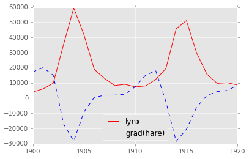

```python
plt.plot(year, lynx, 'r-', year, np.gradient(hare), 'b--')
plt.legend(['lynx', 'grad(hare)'], loc='best')
print np.corrcoef(lynx, np.gradient(hare))
```

# Python 中的数值计算

### NDArray

在 `numpy` 中最基础的结构就是 `ndarray`，是用来表示向量/矩阵/更高维度数组d。每一个`ndarray`都有下面的属性：

- dtype = 对应了在 C语言中的数据类型
- shape = array 数组的数值维度
- strides = 遍历数组时候，每个方向上的二进制值的步长（number of bytes to step in each direction when traversing the array）

```python
x = np.array([1,2,3,4,5,6])
print x
print 'dytpe', x.dtype
print 'shape', x.shape
print 'strides', x.strides
```

```
[1 2 3 4 5 6]
dytpe int64
shape (6,)
strides (8,)
```

```python
x.shape = (2,3)
print x
print 'dytpe', x.dtype
print 'shape', x.shape
print 'strides', x.strides
```

```
[[1 2 3]
 [4 5 6]]
dytpe int64
shape (2, 3)
strides (24, 8)
```

```python
x = x.astype('complex')
print x
print 'dytpe', x.dtype
print 'shape', x.shape
print 'strides', x.strides
```

```
[[ 1.+0.j  2.+0.j  3.+0.j]
 [ 4.+0.j  5.+0.j  6.+0.j]]
dytpe complex128
shape (2, 3)
strides (48, 16)
```

### 创建数组

```python
# 从列表list生成数组
x_list = [(i,j) for i in range(2) for j in range(3)]
print x_list, '\n'
x_array = np.array(x_list)
print x_array
```

```
[(0, 0), (0, 1), (0, 2), (1, 0), (1, 1), (1, 2)]

[[0 0]
 [0 1]
 [0 2]
 [1 0]
 [1 1]
 [1 2]]
```

```python
# 使用特定函数来生成数组

print np.ones((3,2)), '\n'
print np.zeros((3,2)), '\n'
print np.eye(3), '\n'
print np.diag([1,2,3]), '\n'
print np.fromfunction(lambda i, j: (i-2)**2+(j-2)**2, (5,5))
```

```
[[ 1.  1.]
 [ 1.  1.]
 [ 1.  1.]]

[[ 0.  0.]
 [ 0.  0.]
 [ 0.  0.]]

[[ 1.  0.  0.]
 [ 0.  1.  0.]
 [ 0.  0.  1.]]

[[1 0 0]
 [0 2 0]
 [0 0 3]]

[[ 8.  5.  4.  5.  8.]
 [ 5.  2.  1.  2.  5.]
 [ 4.  1.  0.  1.  4.]
 [ 5.  2.  1.  2.  5.]
 [ 8.  5.  4.  5.  8.]]
```

### 数组索引

```python
# 创建一个 10 * 6 的数组，基于正态分布，然后转换成 int 值
n, nrows, ncols = 100, 10, 6
xs = np.random.normal(n, 15, size=(nrows, ncols)).astype('int')
xs
```

```
array([[ 82,  94,  86, 114,  88, 115],
       [104,  84, 103,  87,  86,  96],
       [105,  87,  72, 113,  82, 104],
       [124, 103,  79,  88, 128,  87],
       [111, 101, 104, 104,  90,  82],
       [ 94, 110,  89,  89, 112,  97],
       [132, 122, 102, 108,  93, 108],
       [ 89,  80, 112,  96, 107,  73],
       [128, 104,  99, 107,  98, 132],
       [100,  73,  92,  92, 117,  99]])
```

```python
# 使用切片标示符号
print(xs[0,0])
print(xs[-1,-1])
print(xs[3,:])
print(xs[:,0])
print(xs[::2,::2])
print(xs[2:5,2:5])
```

```
82
99
[124 103  79  88 128  87]
[ 82 104 105 124 111  94 132  89 128 100]
[[ 82  86  88]
 [105  72  82]
 [111 104  90]
 [132 102  93]
 [128  99  98]]
[[ 72 113  82]
 [ 79  88 128]
 [104 104  90]]
```

```python
#  对整数列表进行索引
print(xs[0, [1,2,4,5]])
```

```
[ 94  86  88 115]
```

```python
# 布尔值进行索引（Boolean indexing）
print(xs[xs % 2 == 0])
xs[xs % 2 == 0] = 0 # 设置每个值都为0
print(xs)
```

```
[ 82  94  86 114  88 104  84  86  96  72  82 104 124  88 128 104 104  90
  82  94 110 112 132 122 102 108 108  80 112  96 128 104  98 132 100  92
  92]
[[  0   0   0   0   0 115]
 [  0   0 103  87   0   0]
 [105  87   0 113   0   0]
 [  0 103  79   0   0  87]
 [111 101   0   0   0   0]
 [  0   0  89  89   0  97]
 [  0   0   0   0  93   0]
 [ 89   0   0   0 107  73]
 [  0   0  99 107   0   0]
 [  0  73   0   0 117  99]]
```

```python
# 导出下三角矩阵，对角矩阵，上三角矩阵

a = np.arange(16).reshape(4,4)
print a, '\n'
print np.tril(a, -1), '\n'
print np.diag(np.diag(a)), '\n'
print np.triu(a, 1)
```

```
[[ 0  1  2  3]
 [ 4  5  6  7]
 [ 8  9 10 11]
 [12 13 14 15]]

[[ 0  0  0  0]
 [ 4  0  0  0]
 [ 8  9  0  0]
 [12 13 14  0]]

[[ 0  0  0  0]
 [ 0  5  0  0]
 [ 0  0 10  0]
 [ 0  0  0 15]]

[[ 0  1  2  3]
 [ 0  0  6  7]
 [ 0  0  0 11]
 [ 0  0  0  0]]
```

### 广播（Broadcasting）, 行/列和矩阵运算（row, column，matrix operations）

```python
# 对整个矩阵或者其中的各个行或者列来进行计算
print(xs.max())
print(xs.max(axis=0)) # 每列最大值
print(xs.max(axis=1)) # 每行最大值
```

```
117
[111 103 103 113 117 115]
[115 103 113 103 111  97  93 107 107 117]
```

```python
# 不使用面向对象的方法，而使用函数也能实现
print(np.max(xs, axis=0))
print(np.max(xs, axis=1))
```

```
[111 103 103 113 117 115]
[115 103 113 103 111  97  93 107 107 117]
```

```python
# 广播broadcasting
xs = np.arange(12).reshape(2,6)
print(xs, '\n')
print(xs * 10, '\n')

# 广播直接就能适用于进行列操作的情况
col_means = xs.mean(axis=0)
print(col_means, '\n')
print(xs + col_means, '\n')

# 但用到行操作的时候就要稍微麻烦一点
row_means = xs.mean(axis=1)[:, np.newaxis]
print(row_means)
print(xs + row_means)
```

```
(array([[ 0,  1,  2,  3,  4,  5],
       [ 6,  7,  8,  9, 10, 11]]), '\n')
(array([[  0,  10,  20,  30,  40,  50],
       [ 60,  70,  80,  90, 100, 110]]), '\n')
(array([ 3.,  4.,  5.,  6.,  7.,  8.]), '\n')
(array([[  3.,   5.,   7.,   9.,  11.,  13.],
       [  9.,  11.,  13.,  15.,  17.,  19.]]), '\n')
[[ 2.5]
 [ 8.5]]
[[  2.5   3.5   4.5   5.5   6.5   7.5]
 [ 14.5  15.5  16.5  17.5  18.5  19.5]]
```

```python
# 对矩阵进行转换，使其平均值为零，然后将标准差使用列的总体统计来进行标准化
print((xs - xs.mean(axis=0))/xs.std(axis=0))
```

```
[[-1. -1. -1. -1. -1. -1.]
 [ 1.  1.  1.  1.  1.  1.]]
```

```python
# 对矩阵进行转换，使其平均值为零，然后将标准差使用行的总体统计来进行标准化
print((xs - xs.mean(axis=1)[:, np.newaxis])/xs.std(axis=1)[:, np.newaxis])
```

```
[[-1.4639 -0.8783 -0.2928  0.2928  0.8783  1.4639]
 [-1.4639 -0.8783 -0.2928  0.2928  0.8783  1.4639]]
```

```python
# 用外积进行广播（broadcasting for outer product）
# 例如：创建一个 12x12 的乘法表
u = np.arange(1, 13)
u[:,None] * u[None,:]
```

```
array([[  1,   2,   3,   4,   5,   6,   7,   8,   9,  10,  11,  12],
       [  2,   4,   6,   8,  10,  12,  14,  16,  18,  20,  22,  24],
       [  3,   6,   9,  12,  15,  18,  21,  24,  27,  30,  33,  36],
       [  4,   8,  12,  16,  20,  24,  28,  32,  36,  40,  44,  48],
       [  5,  10,  15,  20,  25,  30,  35,  40,  45,  50,  55,  60],
       [  6,  12,  18,  24,  30,  36,  42,  48,  54,  60,  66,  72],
       [  7,  14,  21,  28,  35,  42,  49,  56,  63,  70,  77,  84],
       [  8,  16,  24,  32,  40,  48,  56,  64,  72,  80,  88,  96],
       [  9,  18,  27,  36,  45,  54,  63,  72,  81,  90,  99, 108],
       [ 10,  20,  30,  40,  50,  60,  70,  80,  90, 100, 110, 120],
       [ 11,  22,  33,  44,  55,  66,  77,  88,  99, 110, 121, 132],
       [ 12,  24,  36,  48,  60,  72,  84,  96, 108, 120, 132, 144]])
```

#### 样例：使用 broadcasting 和 vectorization 计算间距矩阵（pairwise distance matrix）

计算下面的各个点的距离矩阵

- (0,0)
- (4,0)
- (4,3)
- (0,3)

```python
def distance_matrix_py(pts):
    """返回欧几里德距离矩阵，纯Python版本"""
    n = len(pts)
    p = len(pts[0])
    m = np.zeros((n, n))
    for i in range(n):
        for j in range(n):
            s = 0
            for k in range(p):
                s += (pts[i,k] - pts[j,k])**2
            m[i, j] = s**0.5
    return m
```

```python
def distance_matrix_np(pts):
    """返回欧几里德距离矩阵，使用向量的numpy版本"""
    return np.sum((pts[None,:] - pts[:, None])**2, -1)**0.5
```

```python
pts = np.array([(0,0), (4,0), (4,3), (0,3)])
```

```python
distance_matrix_py(pts)
```

```
array([[ 0.,  4.,  5.,  3.],
       [ 4.,  0.,  3.,  5.],
       [ 5.,  3.,  0.,  4.],
       [ 3.,  5.,  4.,  0.]])
```

```python
distance_matrix_np(pts)
```

```
array([[ 0.,  4.,  5.,  3.],
       [ 4.,  0.,  3.,  5.],
       [ 5.,  3.,  0.,  4.],
       [ 3.,  5.,  4.,  0.]])
```

```python
# Broaccasting 和 vectorization 的速度远远比循环要快得多
%timeit distance_matrix_py(pts)
%timeit distance_matrix_np(pts)
```

```
1000 loops, best of 3: 199 µs per loop
10000 loops, best of 3: 31.4 µs per loop
```